# Assignemnt 1

Let us read the data. THe following code assumes that the csv file is already loaded and unzipped into the working directory.

```r
dat<-read.csv("activity.csv")
```

Let us calculate the total number of step per day. The Na’s are just ignored. After calculation the histogram is build, which shows the correspoding distribution density.

```r
total_day<-aggregate( steps ~ date, data = dat, FUN = sum, na.rm = TRUE)
head(total_day)
```

```
##         date steps
## 1 2012-10-02   126
## 2 2012-10-03 11352
## 3 2012-10-04 12116
## 4 2012-10-05 13294
## 5 2012-10-06 15420
## 6 2012-10-07 11015
```

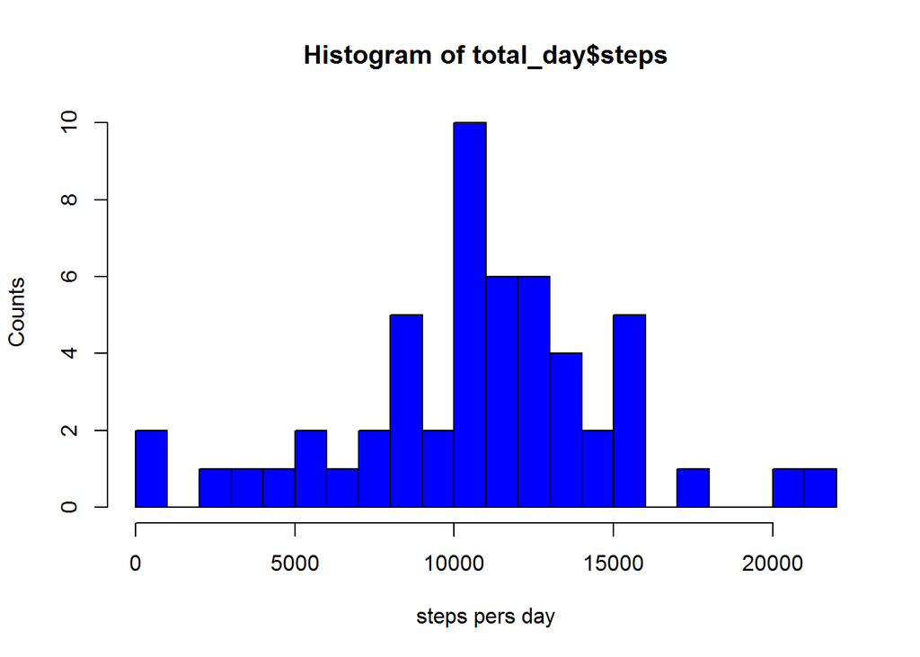

```r
hist(total_day$steps, xlab="steps pers day", ylab=" Counts", col="blue", breaks=20)
```

Calculate the mean and median number of steps taken per day.

```r
steps_mean<- mean(total_day$steps)
steps_mean
```

```
## [1] 10766.19
```

```r
steps_median<- median(total_day$steps)
steps_median
```

```
## [1] 10765
```

Make a time series plot (i.e. type = “l”) of the 5-minute interval (x-axis) and the average number of steps taken, averaged across all days (y-axis)

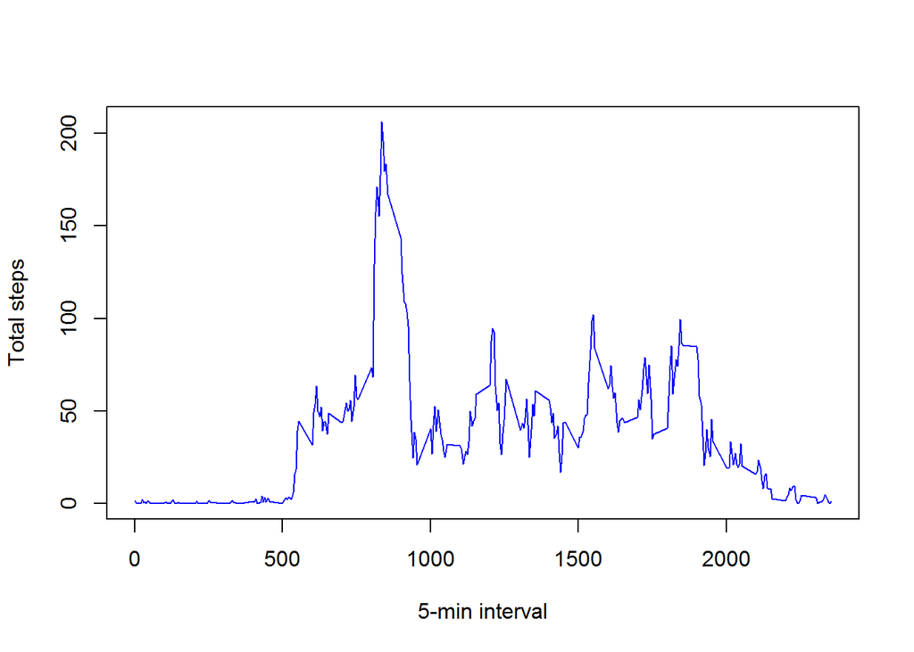

```r
total_interval<-aggregate( steps ~ interval, data = dat, FUN = mean, na.rm = TRUE)
plot(total_interval$interval, total_interval$steps, type="l", xlab="5-min interval",
             ylab= "Total steps", col="blue")
```

Which 5-minute interval, on average across all the days in the dataset, contains the maximum number of steps?

Max number of steps

```r
max_steps_int<-max(total_interval$steps)
max_steps_int
```

```
## [1] 206.1698
```

**Interval containing max number of steps in average:**

```r
#interval with max number of steps
total_interval$interval[which(total_interval$steps==max_steps_int)]
```

```
## [1] 835
```

## Imputing missing values

How many missing values do we have?

```r
steps_na<-length(dat$steps[dat$steps=="NA"])
steps_na
```

```
## [1] 2304
```

looks like a lot!!!!

How does it look like?

```r
head(dat$steps, 20)
```

```
##  [1] NA NA NA NA NA NA NA NA NA NA NA NA NA NA NA NA NA NA NA NA
```

### Let us impute the missing values with average numer of steps per corresponding tiem interval.

Calculating mean number of steps per interval, ignoiring missing values. Showing first 30 intervals.

```r
mean_interval<-aggregate( steps ~ interval, data = dat, FUN = mean, na.rm = TRUE)
head(mean_interval, 30)
```

```
##    interval     steps
## 1         0 1.7169811
## 2         5 0.3396226
## 3        10 0.1320755
## 4        15 0.1509434
## 5        20 0.0754717
## 6        25 2.0943396
## 7        30 0.5283019
## 8        35 0.8679245
## 9        40 0.0000000
## 10       45 1.4716981
## 11       50 0.3018868
## 12       55 0.1320755
## 13      100 0.3207547
## 14      105 0.6792453
```

[output cut: 16 more lines]

Creating an impute function, which replaces the missing values with the mean over the interval. The later are looked up in the dataframe *mean_interval*

```r
impute<-function(interval){
        i<-which(mean_interval$interval==interval)
        mean_interval$steps[i]
}
```

Let us now replace all the NAs with the corresponding means.

```r
dat$steps[is.na(dat$steps)]<-impute(dat$interval[is.na(dat$steps)])
head(dat$steps, 20)
```

```
##  [1] 1.7169811 0.3396226 0.1320755 0.1509434 0.0754717 2.0943396 0.5283019
##  [8] 0.8679245 0.0000000 1.4716981 0.3018868 0.1320755 0.3207547 0.6792453
## [15] 0.1509434 0.3396226 0.0000000 1.1132075 1.8301887 0.1698113
```

It looks like we’ve done that!!!

Now we make the same plots but with the rectified dataset. Total number of steps per day:

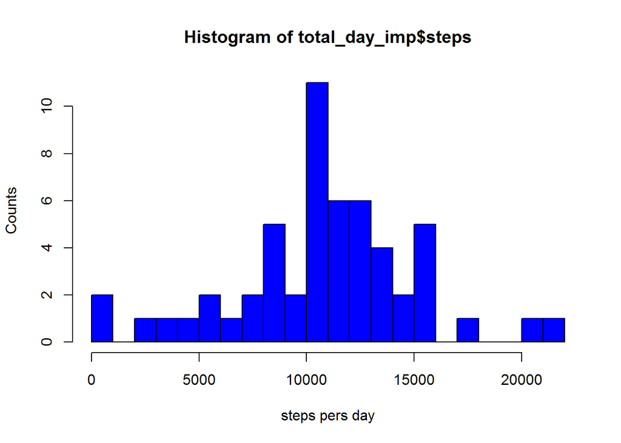

```r
total_day_imp<-aggregate(steps ~ date, data = dat, FUN = sum, na.rm = TRUE)
hist(total_day_imp$steps, xlab="steps pers day", ylab=" Counts", col="blue", breaks=20)
```

Calculate the mean and median number of steps taken per day.

```r
steps_mean_imp<- mean(total_day_imp$steps)
print("mean od number of steps per day")
```

```
## [1] "mean od number of steps per day"
```

```r
steps_mean_imp
```

```
## [1] 10766.19
```

```r
steps_med_imp<- median(total_day_imp$steps)
print("meadian of number of steps per day")
```

```
## [1] "meadian of number of steps per day"
```

```r
steps_med_imp
```

```
## [1] 10765.59
```

**There is not much difference in this particular case between original and imputted datasets**

## Are there differences in activity patterns between weekdays and weekends?

is it a weekday or weekend? creating a function, which returns the answer:

```r
wd<-function(date){
        if(weekdays(date)=="Saturday" | weekdays(date)=="Sunday") as.factor("weekend")
        else as.factor("weekday")
}
```

Creating a corresponding factor variable in the imputed dataset.

```r
dat$wdays<-sapply(as.Date(dat$date), wd)
head(dat, 10)
```

```
##        steps       date interval   wdays
## 1  1.7169811 2012-10-01        0 weekday
## 2  0.3396226 2012-10-01        5 weekday
## 3  0.1320755 2012-10-01       10 weekday
## 4  0.1509434 2012-10-01       15 weekday
## 5  0.0754717 2012-10-01       20 weekday
## 6  2.0943396 2012-10-01       25 weekday
## 7  0.5283019 2012-10-01       30 weekday
## 8  0.8679245 2012-10-01       35 weekday
## 9  0.0000000 2012-10-01       40 weekday
## 10 1.4716981 2012-10-01       45 weekday
```

calculating mean number of steps per interval with the rectified dataset. Showing first 20 intervals.

```r
mean_interval_imp<-aggregate( steps ~ interval + wdays, data = dat, FUN = mean, na.rm = TRUE)
head(mean_interval_imp, 20)
```

```
##    interval   wdays       steps
## 1         0 weekday 2.317924528
## 2         5 weekday 0.458490566
## 3        10 weekday 0.178301887
## 4        15 weekday 0.203773585
## 5        20 weekday 0.101886792
## 6        25 weekday 1.527358491
## 7        30 weekday 0.713207547
## 8        35 weekday 1.171698113
## 9        40 weekday 0.000000000
## 10       45 weekday 1.836792453
## 11       50 weekday 0.407547170
## 12       55 weekday 0.003301887
## 13      100 weekday 0.433018868
## 14      105 weekday 0.016981132
## 15      110 weekday 0.203773585
## 16      115 weekday 0.458490566
## 17      120 weekday 0.000000000
## 18      125 weekday 1.502830189
## 19      130 weekday 2.270754717
## 20      135 weekday 0.004245283
```

Make a panel plot containing a time series plot (i.e.type = “l”) of the 5-minute interval (x-axis) and the average number of steps taken, averaged across all weekday days or weekend days (y-axis)

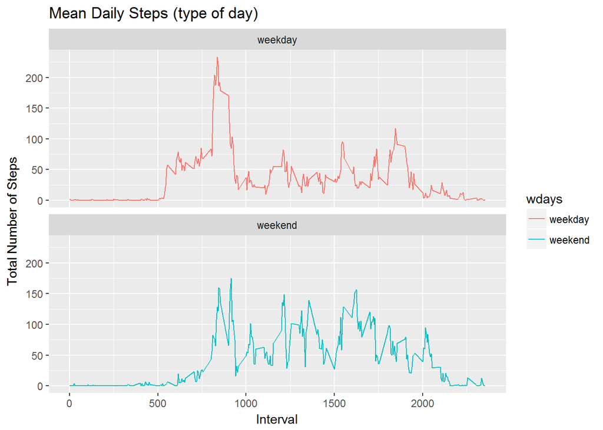

```r
library(ggplot2)
ggplot(mean_interval_imp, aes(x =interval , y=steps, color=wdays)) +
       geom_line() +
       labs(title = "Mean Daily Steps (type of day)", x = "Interval", y = "Total Number of Steps") +
       facet_wrap(~ wdays, ncol = 1, nrow=2)
```